# Exam 2

## Exam 2

#### Question

1. In a deck of strange cards, there are 1377 cards. Each card has an image and a color. The amounts are shown in the table below.

   |  | gray | orange | violet | white | yellow |
   | --- | --- | --- | --- | --- | --- |
   | dog | 44 | 99 | 72 | 73 | 57 |
   | horn | 20 | 23 | 91 | 74 | 48 |
   | pig | 22 | 31 | 45 | 52 | 67 |
   | tree | 63 | 37 | 11 | 58 | 83 |
   | wheel | 70 | 89 | 77 | 12 | 59 |

   1. What is the probability a random card is either a tree or orange (or both)?
   2. What is the probability a random card is orange?
   3. What is the probability a random card is a pig?
   4. What is the probability a random card is a horn given it is yellow?
   5. What is the probability a random card is violet given it is a pig?
   6. What is the probability a random card is both a dog and white?

#### Solution

   1. $P(\text{tree or orange})$ $=\frac{63+37+11+58+83+99+23+31+37+89-37}{1377}=0.359$
   2. $P(\text{orange})$ $=\frac{99+23+31+37+89}{1377}=0.203$
   3. $P(\text{pig})$ $=\frac{22+31+45+52+67}{1377}=0.158$
   4. $P(\text{horn given yellow})$ $=\frac{48}{57+48+67+83+59}=0.153$
   5. $P(\text{violet given pig})$ $=\frac{45}{22+31+45+52+67}=0.207$
   6. $P(\text{dog and white})$ $=\frac{73}{1377}=0.053$

#### Question

2. In a deck of strange cards, each card has an image and a color. The chance of drawing a bike is 25.3%. If a bike is drawn, there is a 81.7% chance that it is orange. If a card that is not a bike is drawn, there is a 44% chance that it is orange.

   Now, someone draws a random card and reveals it is orange. What is the chance the card is not a bike?

#### Solution

   I'd recommend making a tree. Remember, on the first branch, we put simple probabilities. On the second branches we put conditional probabilites. The results (products) are joint probabilities.

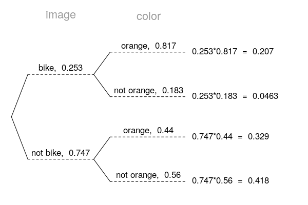

   Determine the appropriate conditional probability.
   $$P(\text{"not bike" given "orange"}) = \frac{0.329}{0.329+0.207} = 0.614$$

#### Question

3. In a very large pile of toothpicks, the mean length is 60.28 millimeters and the standard deviation is 1.65 millimeters. If you randomly sample 120 toothpicks, what is the chance the sample mean is between 60.12 and 60.52 millimeters?

#### Solution

   Label the given information.
   $$\begin{aligned}
   \mu &= 60.28\\
   \sigma &= 1.65\\
   n &= 120\\
   \bar{x}_\text{lower} &= 60.12 \\
   \bar{x}_\text{upper} &= 60.52
   \end{aligned}$$
   Find the standard error.
   $$SE = \frac{\sigma}{\sqrt{n}} = \frac{1.65}{\sqrt{120}} = 0.151$$
   Describe the sampling distribution.
   $$\bar{X} \sim \mathcal{N}(60.28,\,0.151)$$

   Draw a sketch.

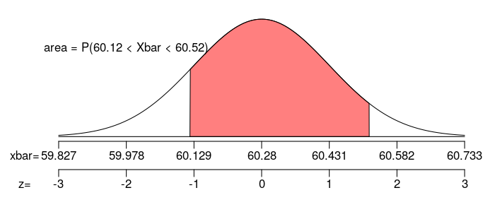

   Calculate a $z$ scores.
   $$z_\text{lower} = \frac{x_\text{lower}-\mu}{SE} = \frac{60.12-60.28}{0.151} = -1.06$$
   $$z_\text{upper} = \frac{x_\text{upper}-\mu}{SE} = \frac{60.52-60.28}{0.151} = 1.59$$
   Determine the probability.
   $$\begin{aligned}
   P(60.12 < X < 60.52) &= \Phi(z_\text{upper}) - \Phi(z_\text{lower}) \\
   &= \Phi(1.59) - \Phi(-1.06) \\
   &= 0.7995
   \end{aligned}$$

#### Question

4. In a game, there is a 43% chance to win a round. You will play 65 rounds.
   1. What is the probability of winning exactly 28 rounds?
   2. What is the probability of winning at least 24 but at most 34 rounds?

#### Solution

   We use the formula for binomial probabilities.
   $$P(X=k) = {n \choose k} (p)^{k}(1-p)^{n-k}$$
   $$P(X=28) = {65 \choose 28} (0.43)^{28}(1-0.43)^{65-28}$$
   $$P(X=28) = {65 \choose 28} (0.43)^{28}(0.57)^{37}$$
   $$P(X=28) = 0.0995$$

   Find the mean.
   $$\mu = np = (65)(0.43) = 27.95$$
   Find the standard deviation.
   $$\sigma = \sqrt{np(1-p)} = \sqrt{(65)(0.43)(1-0.43)} = 3.9914$$
   Make a sketch, specifically try to picture whether you need to add or subtract 0.5 for the continuity correction.

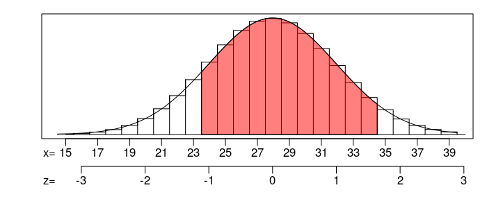

   Find the $z$ scores.
   $$z_1 = \frac{23.5-27.95}{3.9914} = -1.11$$

   $$z_2 = \frac{34.5-27.95}{3.9914} = 1.64$$
   Calculate the probability.
   $$P(24\le X \le 34) = \Phi(1.64) - \Phi(-1.11) = 0.816$$
   1. $P(X=28) = 0.0995$
   2. $P(24 \le X \le 34) = 0.816$

#### Question

5. As an ornithologist, you wish to determine the average body mass of *Passerculus sandwichensis*. You randomly sample 36 adults of *Passerculus sandwichensis*, resulting in a sample mean of 17.26 grams and a sample standard deviation of 1.67 grams. Determine a 99% confidence interval of the true population mean.

#### Solution

   We are given the sample size, sample mean, sample standard deviation, and confidence level.
   $$\begin{aligned}
   n &= 36 \\
   \bar{x} &= 17.26 \\
   s &= 1.67\\
   CL &= 0.99
   \end{aligned}$$
   Determine the degrees of freedom (because we don't know $\sigma$ and we are doing inference so we need to use the $t$ distribution).
   $$df = n-1 = 35$$
   Determine the critical $t$ value, $t^\star$, such that $P(|T|<t^\star) = 0.99$.
   $$t^\star = 2.72$$
   Calculate the standard error.
   $$SE = \frac{s}{\sqrt{n}} = \frac{1.67}{\sqrt{36}} = 0.278$$
   We want to make an inference about the population mean.
   $$\mu ~\approx~ \bar{x}\pm t^\star SE$$
   Determine the bounds.
   $$\begin{aligned}
   CI &= (\bar{x} - t^\star SE,\,\bar{x} + t^\star SE) \\
   &= (17.26 - 2.72\times0.278,\,17.26 + 2.72\times0.278) \\
   &= (16.5,\,18)
   \end{aligned}$$
   We are 99% confident that the population mean is between 16.5 and 18.

#### Question

6. A treatment group of size 23 has a mean of 115 and standard deviation of 16.8. A control group of size 36 has a mean of 103 and standard deviation of 23.9. If you decided to use a signficance level of 0.02, is there sufficient evidence to conclude the treatment causes an effect?

   By using the Welch-Satterthwaite equation, I've calculated the degrees of freedom should be 56.
   1. State the null hypothesis.
   2. State the alternative hypothesis.
   3. Evaluate the critical value. (The critical value is either $z^\star$ or $t^\star$. Determine its value.)
   4. Determine the standard error of the relevant sampling distribution.
   5. Evaluate the absolute value of the test statistic. (The test statistic is either $z_\text{obs}$ or $t_\text{obs}$. Determine its absolute value.)
   6. If possible, evaluate the $p$-value. Otherwise, describe an interval containing the $p$-value.
   7. Do we reject or retain the null?

#### Solution

   We are given unpaired data. We are considering a difference of means. Label the given information.
   $$\begin{aligned}
   n_1 &= 23 \\
   \bar{x}_1 &= 115\\
   s_1 &= 16.8\\
   n_2 &= 36 \\
   \bar{x}_2 &= 103\\
   s_2 &= 23.9\\
   \alpha &= 0.02 \\
   df &= 56
   \end{aligned}$$
   State the hypotheses.
   $$H_0:~~\mu_2-\mu_1 = 0$$
   $$H_A:~~\mu_2-\mu_1 \ne 0$$
   We are using a two-tail test. Find $t^{\star}$ such that $P(|T|>t^{\star})=0.02$ by using a $t$ table.
   $$t^{\star} = 2.39$$
   Calculate the standard error.
   $$\begin{aligned}
   SE &= \sqrt{\frac{(s_1)^2}{n_1}+\frac{(s_2)^2}{n_2}} \\
   &= \sqrt{\frac{(16.8)^2}{23}+\frac{(23.9)^2}{36}} \\
   &= 5.305
   \end{aligned}$$
   Determine the test statistic.
   $$\begin{aligned}
   t_\text{obs} &= \frac{(\bar{x}_2-\bar{x}_1)-(\mu_2-\mu_1)_0}{SE} \\
   &= \frac{(103-115)-(0)}{5.305} \\
   &= -2.26
   \end{aligned}$$
   Compare $|t_\text{obs}|$ and $t^\star$.
   $$|t_\text{obs}| < t^\star$$
   We can determine an interval for the $p$-value using the $t$ table.
   $$0.02 < p\text{-value} < 0.04$$
   Compare $p$-value and $\alpha$.
   $$p\text{-value} > \alpha$$
   We conclude that we should retain the null hypothesis.
   1. $H_0: ~~\mu_2-\mu_1=0$
   2. $H_\text{A}:~~ \mu_2-\mu_1\ne 0$
   3. $t^\star = 2.39$
   4. $SE = 5.305$
   5. $|t_\text{obs}| = 2.26$
   6. $0.02 < p\text{-value} < 0.04$
   7. retain the null

#### Question

7. From a very large population, a random sample of 36000 individuals was taken. In that sample, 54% were asleep. Determine a 80% confidence interval of the population proportion.
   1. Find the lower bound of the confidence interval.
   2. Find the upper bound of the condifence interval.

#### Solution

   Determine $z^\star$ such that $P(|Z|<z^\star) = 0.8$.
   $$z^\star = 1.28$$
   Calculate the standard error.
   $$SE = \sqrt{\frac{\hat{p}(1-\hat{p})}{n}} = \sqrt{\frac{(0.54)(1-0.54)}{36000}} = 0.00263$$
   Calculate the margin of error.
   $$ME = z^\star SE = (1.28)(0.00263) = 0.00337$$
   To find the confidence interval's bounds, find the sample proportion plus or minus the margin of error.
   $$p ~\approx~ \hat{p} \pm ME$$
   Determine the interval.
   $$(0.537\,,~ 0.543)$$
   We are 80% confident that the true population proportion is between 53.7% and 54.3%.
   1. The lower bound = 0.537, which can also be expressed as 53.7%.
   2. The upper bound = 0.543, which can also be expressed as 54.3%.

#### Question

8. An experiment is run with a treatment group of size 252 and a control group of size 266. The results are summarized in the table below.

   |  | treatment | control |
   | --- | --- | --- |
   | happy | 183 | 216 |
   | not happy | 69 | 50 |

   Using a significance level of 0.04, determine whether the treatment causes an effect on the proportion of cases that are happy.
   1. State the null hypothesis.
   2. State the alternative hypothesis.
   3. Evaluate the critical value. (The critical value is either $z^\star$ or $t^\star$. Determine its value.)
   4. Determine the standard error of the relevant sampling distribution.
   5. Evaluate the absolute value of the test statistic. (The test statistic is either $z_\text{obs}$ or $t_\text{obs}$. Determine its absolute value.)
   6. If possible, evaluate the $p$-value. Otherwise, describe an interval containing the $p$-value.
   7. Do we reject or retain the null?

#### Solution

   State the hypotheses.
   $$H_0:~~ p_2-p_1 = 0$$
   $$H_\text{A}: ~~ p_2-p_1 \ne 0$$
   Find $z^\star$ such that $P(|Z|>z^\star) = 0.04$.
   $$z^\star = \Phi^{-1}\left(1-\frac{\alpha}{2}\right) = 2.05$$
   Determine the sample proportions.
   $$\hat{p}_1 = \frac{183}{252} = 0.726$$
   $$\hat{p}_2 = \frac{216}{266} = 0.812$$
   Determine the difference of sample proportions.
   $$\hat{p}_2-\hat{p}_1 = 0.812-0.726 = 0.086$$
   Determine the pooled proportion (because the null assumes the population proportions are equal).
   $$\hat{p} = \frac{183+216}{252+266} = 0.77$$
   Determine the standard error.
   $$\begin{aligned}
   SE &= \sqrt{\frac{\hat{p}(1-\hat{p})}{n_1}+\frac{\hat{p}(1-\hat{p})}{n_2}} \\[1em]
   &= \sqrt{\frac{(0.77)(0.23)}{252}+\frac{(0.77)(0.23)}{266}} \\[1em]
   &= 0.037
   \end{aligned}$$
   We can be more specific about what the null hypothesis claims.
   $$H_0:~~~~ \hat{P}_2-\hat{P}_1 ~\sim~ \mathcal{N}(0,\,0.037)$$
   We want to describe how unusual our observation is under the null by finding the $p$-value. To do so, first find the $z$ score.
   $$\begin{aligned}
   z &= \frac{(\hat{p}_2-\hat{p}_1)-(p_2-p_1)_0}{SE}\\
   &= \frac{(0.812-0.726)-0}{0.037} \\
   &= 2.32
   \end{aligned}$$
   Determine the $p$-value.
   $$\begin{aligned}
   p\text{-value} &= 2\cdot \Phi(-|z|)\\
   &= 2\cdot \Phi(-2.32)\\
   &= 0.0204
   \end{aligned}$$
   Compare the $p$-value to the signficance level.
   $$p\text{-value} < \alpha$$
   So, we reject the null hypothesis. Thus the difference in proportions is significant.
   1. $H_0: ~~p_2-p_1=0$
   2. $H_\text{A}:~~ p_2-p_1\ne 0$
   3. $z^\star = 2.05$
   4. $SE = 0.037$
   5. $|z_\text{obs}| = 2.32$
   6. $p\text{-value} = 0.0204$
   7. reject the null